# Practice Data Analysis Larval Traits

Here we will practice some analyses to use on the larval fish morphology data.

We’re using a R Markdown Document. Here we can type freely, within chunks (grey) to type normal text as notes we have to start the line with a hash (#)

```r
#load packages or apps
#install.packages("tidyverse")
library(lubridate)
library(tidyverse) #if you don't have it installed, you'll have to do that first by
```

Bring in data stored as csvs

```r
photos <- read.csv("DataSheetPhotos_Practice.csv") #You'll have to change this path to match your machine, also note that for Windows, you will need to use backslashes instead of forward slashes (\ versus /)
measurements <- read.csv("/Users/zoekitchel/Documents/grad school/Rutgers/mentoring/Justin/Measurements_practice.csv")
```

Now, let’s take a look at these!

```r
View(photos) #let's view it like a spreadsheet above
summary(photos) #overall summary and statistics
str(photos) #structure, are the columns in the right format?

#check this out for all of the data frames
#numerical columns should be <int> or <dbl>
```

[output not shown]

We also don’t want the data from icthy_data that’s not for our focal species

```r
summary(factor(icthy_data_reduced$Species)) #success!
```

```
 dentatus undulatus
       44        42
```

We now need to merge these data frames together, which columns are the same across data frames?

[output not shown]

Match Spp to Genus Spp -In photos_reduced, species is under spp, but in icthy data species is under genus and species, we have to match them

Now, I’ve noticed that we use Tow_ID in photo data frame, but Tow in icthy_data_reduced data frame, let’s match

```r
icthy_data_reduced$Tow_ID <- icthy_data_reduced$Tow
```

Time to merge!

```r
full_merge_icthyoplankton <- inner_join(icthy_data_photos, measurements, by = c("Code"))
```

[output not shown]

1. How does sample # change by date and location for each species?

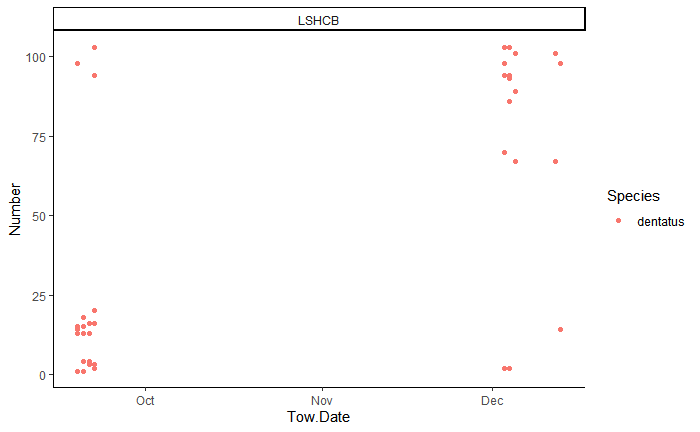

2. Does standard length vary by date? Is this pattern different for different locations and species?

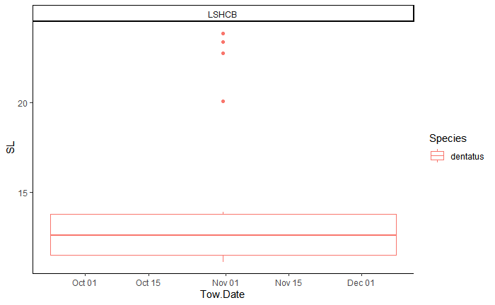

3. Now, we can ask a ton of different questions

Variables to include: - Species - Location - Morphological traits - Number of fish - Temperature - Date

[output not shown]

[output cut: 22 more lines]